# Installing R and basic commands

# Welcome

This tutorial walks you through installing `R` and `RStudio` and running a few basic commands to make sure everything works. It has four parts:

- Installing `R` and `RStudio`
- Setting up a folder for your code and data
- Starting a script file
- Running a quick test: loading a built-in data set, making a table, and making a plot

# Installing `R` and `RStudio`

`R` and `RStudio` are separate programs, and you need both. Install them in this order:

- First, install the newest version of `R`: [**Windows version**](https://cran.r-project.org/bin/windows/base/), [**Mac version**](https://cran.r-project.org/bin/macosx/)
- Then, install `RStudio` (free version): [**Windows and Mac**](https://posit.co/downloads/)

You only need to open `RStudio` to work; it runs `R` in the background.

### `RStudio` layout

Refer to the image below to identify the four panels in `RStudio`:

- **Top left (script):** Where you write, run, and save your code
- **Top right (environment):** Shows the *objects* you create, such as data sets and values
- **Bottom left (console):** Shows the output of your commands, along with any errors
- **Bottom right (plots):** Displays your plots, and can also be used to browse files

[figure not shown]

# Setting up your folder

Create a folder called *R* somewhere easy to find on your computer (for example, in *Documents*). Inside it, create a subfolder called *dat*. Save your script files directly in the *R* folder, and put any data files you receive in *dat*:

```
R/
├── my-script.R    # your code files
└── dat/           # data files
```

Keeping data in its own folder means your code can always find it using the same short file path, such as `"dat/filename.csv"`.

# Starting your script

Open a new script file by going to **File → New File → R Script**, and save it in your *R* folder.

**A few useful tips when coding:**

- Any text after a hashtag (`#`) is not run as code. This is called ‘commenting out’ text, and it is useful for leaving notes to yourself
- Leave blank lines between sections of code, with a short comment describing each step
- To run a line of code, place your cursor on it and press **Ctrl + Enter** (Windows) or **Cmd + Enter** (Mac)

Start your script with a header describing the file. Copy the example below into the top of your script and fill in your details:

```r
###########################################################################
# Project: Getting started with R
# Author: [Your name]
# Date: [Today's date]
###########################################################################
```

Next, add a line that clears the environment. This makes sure you start with a clean slate each time you run the script:

```r
# Clearing environment
rm(list=ls())
```

### Installing and loading packages

`R` relies on user-written packages for many tasks. We will install two:

- **readxl**: Imports Excel files (`.xls` and `.xlsx`) into `R`
- **ggplot2**: Creates high-quality plots

**Important:** You only need to install a package once, so run this line directly in the console (bottom left panel) rather than saving it in your script:

```r
# Install packages (only run this once, in the console)
install.packages(c("readxl", "ggplot2"))
```

Packages must be loaded each time you open `RStudio`. Add these lines to your script below the line that clears the environment:

```r
# Loading packages
library(readxl)      # for reading Excel files
library(ggplot2)     # for creating plots
```

### Setting the working directory

The working directory tells `R` where your files are. Use `setwd()` with the path to your *R* folder. The path must be in quotation marks and use forward slashes `/` only. The path looks different depending on your operating system, so modify the matching example below to fit where you created your folder:

```r
# Setting working directory (Windows)
setwd("C:/Users/yourname/Documents/R")

# Setting working directory (Mac)
setwd("/Users/yourname/Documents/R")
```

Only use the line for your operating system. Notice that Mac paths have no drive letter (like `C:`) and start with a forward slash.

**Not sure what your path is?**

- **Windows:** Open your *R* folder in File Explorer, click the address bar at the top, and copy the path. Windows uses backslashes `\`, so change each one to a forward slash `/` after pasting.
- **Mac:** Right-click your *R* folder in Finder, hold the **Option** key, and select **Copy “R” as Pathname**.

Once this is set, you can load any data file in your *dat* folder with a short path. For example:

```r
# Example: loading data files from the dat folder
mydata <- read_excel("dat/filename.xlsx")   # Excel file
mydata <- read.csv("dat/filename.csv")      # CSV file
```

# Testing that everything works

`R` comes with several built-in data sets, so we can test our setup without downloading anything. We will use `mtcars`, which contains data on 32 car models from a 1974 issue of *Motor Trend* magazine.

### Loading and viewing the data

```r
# Loading built-in data set
data(mtcars)

# Viewing the first six rows
head(mtcars)
```

```
##                    mpg cyl disp  hp drat    wt  qsec vs am gear carb
## Mazda RX4         21.0   6  160 110 3.90 2.620 16.46  0  1    4    4
## Mazda RX4 Wag     21.0   6  160 110 3.90 2.875 17.02  0  1    4    4
## Datsun 710        22.8   4  108  93 3.85 2.320 18.61  1  1    4    1
## Hornet 4 Drive    21.4   6  258 110 3.08 3.215 19.44  1  0    3    1
## Hornet Sportabout 18.7   8  360 175 3.15 3.440 17.02  0  0    3    2
## Valiant           18.1   6  225 105 2.76 3.460 20.22  1  0    3    1
```

You should now see `mtcars` in your environment panel. A few of the variables we will use:

- `mpg`: Miles per gallon
- `cyl`: Number of engine cylinders
- `wt`: Weight (in 1,000 lbs)

### Making a table

The `summary()` command gives descriptive statistics for a variable, and `table()` counts how many observations fall into each category:

```r
# Descriptive statistics for fuel efficiency
summary(mtcars$mpg)
```

```
##    Min. 1st Qu.  Median    Mean 3rd Qu.    Max.
##   10.40   15.43   19.20   20.09   22.80   33.90
```

```r
# Number of cars by cylinder count
table(mtcars$cyl)
```

```
##
##  4  6  8
## 11  7 14
```

The `$` symbol selects a single variable (column) from a data set.

### Making a plot

Finally, let’s use `ggplot2` to plot car weight against fuel efficiency, with points colored by number of cylinders:

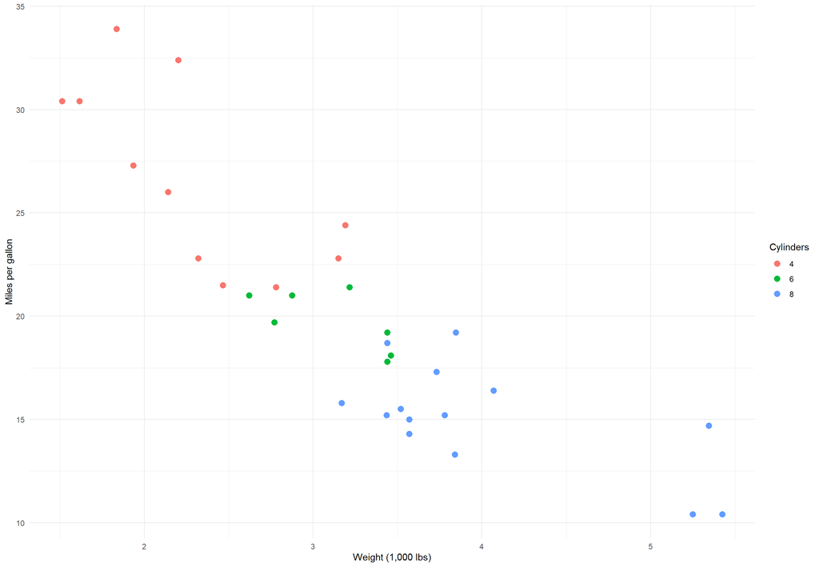

```r
# Scatter plot of weight vs. fuel efficiency
ggplot(mtcars, aes(x = wt, y = mpg, color = factor(cyl))) +
  geom_point(size = 3) +
  labs(x = "Weight (1,000 lbs)",
       y = "Miles per gallon",
       color = "Cylinders") +
  theme_minimal()
```

If the plot appears in your plots panel, `R`, `RStudio`, and your packages are all working correctly.

### Your final script

Your complete script should look like this. Keep only the `setwd()` line for your operating system and delete the other:

```r
###########################################################################
# Project: Getting started with R
# Author: [Your name]
# Date: [Today's date]
###########################################################################

# Clearing environment
rm(list=ls())

# Loading packages
library(readxl)      # for reading Excel files
library(ggplot2)     # for creating plots

# Setting working directory (keep the line for your operating system)
setwd("C:/Users/yourname/Documents/R")   # Windows
setwd("/Users/yourname/Documents/R")     # Mac

# Loading built-in data set
data(mtcars)
head(mtcars)

# Descriptive statistics and table
summary(mtcars$mpg)
table(mtcars$cyl)

# Scatter plot of weight vs. fuel efficiency
ggplot(mtcars, aes(x = wt, y = mpg, color = factor(cyl))) +
  geom_point(size = 3) +
  labs(x = "Weight (1,000 lbs)",
       y = "Miles per gallon",
       color = "Cylinders") +
  theme_minimal()
```

# Finished!

You now have `R` and `RStudio` installed, a folder ready for your data, and a working script.